# noticias_al_desnudo

```python
import requests
import json
import string
from nltk.corpus import stopwords
from collections import deque
import pandas as pd
from bs4 import BeautifulSoup
import matplotlib.pyplot as plt
from datetime import date
import os
```

```python
def dameTitulares(URL, auxTag, auxClase):
    print(f"Filtrando resultados do medio: {URL}")
    _parser = BeautifulSoup(requests.get(URL).content, "html.parser")
    _titulares = _parser.find_all(auxTag, class_=auxClase)
    pilaTitulares = deque()
    enlace = ""

    for _auxTit in _titulares:

        # OJO: añado la URL antes del enlace ya que viene la ruta relativa sólo
        if _auxTit.find("a").get("href")[0] == "/":
            enlace = URL+_auxTit.find("a").get("href")
        else:
            enlace = _auxTit.find("a").get("href")

        pilaTitulares.append([_auxTit.text.strip(),
                               enlace])
    return (pilaTitulares)

# Lectura do arquivo json cargando os datos na variable URLS
with open("medios.json", "r") as f:
    URLS = json.load(f)

print(URLS)
```

```
{'La Voz de Galicia': {'url': 'https://www.lavozdegalicia.es', 'tag': 'h4', 'clase': 'a-min-headline'}, 'El País': {'url': 'https://www.elpais.com', 'tag': 'h2', 'clase': 'c_t'}, 'El Mundo': {'url': 'https://www.elmundo.es', 'tag': 'h2', 'clase': 'ue-c-cover-content-link'}, 'ABC': {'url': 'https://w…
```

```python
allTitulares = deque()
enderezos = json.loads(json.dumps(URLS))

for auxURL in enderezos:
    allTitulares.append(
        dameTitulares(
        enderezos[auxURL]['url'],
        enderezos[auxURL]['tag'],
        enderezos[auxURL]['clase']))

for auxTitular in allTitulares:
    print(auxTitular)
```

```
Filtrando resultados do medio: https://www.lavozdegalicia.es
```

```
Filtrando resultados do medio: https://www.elpais.com
Filtrando resultados do medio: https://www.elmundo.es
Filtrando resultados do medio: https://www.abc.es/
Filtrando resultados do medio: https://www.eleconomista.es/
Filtrando resultados do medio: https://www.vozpopuli.com/
deque([['Junts deja entrever que votará no y reclama una «amnistía integral que no deje a nadie atrás»', 'https://www.lavozdegalicia.es/retransmision/espana/2024/01/30/congreso-vota-ley-amnistia-negativa-junts-apoyar-norma/01071706618179575855971.htm'], ['Abren juicio oral por asesinato contra cinco…
deque([['El texto de la ley de amnistía se tambalea tras retirar Junts su apoyo: “No es lo que firmamos”', 'https://elpais.com/espana/2024-01-30/ultimas-noticias-de-la-actualidad-politica-en-directo.html'], ['El partido de Puigdemont amenaza con rechazar la norma si no se aceptan sus enmiendas sobre…
deque([])
deque([])
deque([])
deque([])
```

## TOP 10 palabras más repetidas

> Primeramente saco los titulares de los deques y los junto en un texto separados por líneas

```python
texto_titulares = ""

for auxTitular in allTitulares:
    if len(auxTitular) != 0:
        for titular in auxTitular:
            texto_titulares += f"{titular[0]}\n" # Cogiendo el primer elemento ya que el segundo es el enlace

print(texto_titulares)
```

```
Junts deja entrever que votará no y reclama una «amnistía integral que no deje a nadie atrás»
Abren juicio oral por asesinato contra cinco acusados de matar a Samuel Luiz en A Coruña
«Na Seguridade Social dixéronme que levaba ano e medio morto»
La inflación repunta tres décimas, hasta el 3,4 %, por la subida de la factura de la luz
Los años negros de la comisaría de Ourense: robo de pistolas, anónimos y una muerte ahora archivada
Elon Musk anuncia que ya se implantó el primer chip cerebral de Neuralink en un ser humano
Casi 1.200 gallegos perdieron la pensión no contributiva en el 2023 por superar el tope de ingresos
El italiano que mató a su expareja en Torremolinos también reconoce que emparedó a otra novia, pero que no la asesinó
Las protestas de los agricultores europeos llegarán a España, pero serán «por regiones»
Así participaron siete profesores de las escuelas de la ONU en la masacre de Hamás
Un conductor de 24 años, pillado en Lugo circulando a 206 kilómetros por hora en un tramo limitado a 100
Ayuda desde Suiza para la maltratada sin trabajo de Ribeira: «Cuando vi el titular y la foto en La Voz quedé bloqueada y hundida en la miseria»
Once años de cárcel para una educadora social por abusar de una menor de 13 años en un centro de Redondela
Felipe Oróns: «Estiven unha hora con todo o peso do Mercedes enriba do brazo»
El Celta cambia el césped de Balaídos por cuarta vez esta temporada
El rey Felipe VI cumple 56 años: «Vamos tirando»
Un nuevo anticiclón de bloqueo protegerá a Galicia
Las calçotadas se ponen de moda en Galicia: dónde, cómo y cúando disfrutarlas
Dejaron Venezuela tras un secuestro y montaron un taller en Pontevedra: «No podíamos seguir sufriendo»
El hartazgo de una santiaguesa por un árbol que se cuela en su salón: «Llevamos 20 años con estas vistas»
Acusa a su abogado de arruinarla: «Acabó con lo mío, con lo de mi hija, y con nuestra salud»
Expulsan a un grupo de vecinos de Becerreá del pleno de la Diputación
Rueda pide una mayoría para que «Galicia no se convierta en lo que pasa en otras partes de España»
Pontón plantea una «bolsa de vivenda» con las tres universidades para los pisos de los estudiantes
El PSdeG reivindica ser «o único con capacidade de xestión para rescatar» la sanidad pública
Un vecino de Cabanas que adquirió un híbrido: «Si llega a ser hoy, me compro un coche de gasoil»
Ribeira de Piquín, un oasis de menos de 500 personas que busca sobrevivir: «O ano pasado naceu unha nena»
El administrador de fincas acusado de apropiarse de 175.000 euros de una comunidad de vecinos, en el banquillo: «Él los engañó, literalmente»
Adiós a Luis Gómez, exjefe de la Policía Local de Bueu
Cataluña-Galicia, una odisea en tren
¿De quién depende la fiscalía?
La nacionalización de la campaña
Vivo con fibromialgia
Tras haber superado el medio siglo de existencia, ¿he sido feliz?
As once caras
Alcoa inicia «in extremis» el proceso para arrancar las primeras cubas
La reducción de jornada «no tendría que afectar a la productividad», según Economía
El delegado del Gobierno asegura que Altri tendrá conexión eléctrica
Los empleados que emitan facturas falsas a espaldas de la empresa están obligados a pagar el IVA
La eurozona esquivó la entrada en recesión en el 2023
```

[output cut: 218 more lines]

```
Aborrajados colombianos
‘Mac and cheese’ de autor con solo tres ingredientes
¿Llegaremos a hablar con los animales?
Vivir en el futuro, orientarnos en un mundo nuevo
Diez productos del ‘outlet’ de Ikea ‘online’ que no puedes dejar escapar
Así son los grifos superventas disponibles en Amazon desde solo 29,99 euros
Ocho regalos gourmet para regalar en San Valentín
Cómo quitar el sarro de los dientes con estos productos básicos
Los mejores jamoneros para cortar jamón de forma cómoda
‘Brianeitor’, el nominado al Goya a quien los médicos dieron días de vida
José Manuel Soto da su opinión sobre el cartel de la semana santa de Sevilla: sorprenderá a muchos
Mbappé, desenlace inminente
Microclimax musical: ¿por qué las canciones duran cada vez menos?
Arturo Pérez-Reverte y su contundente respuesta sobre ‘Griselda’, el último gran estreno de Netflix
El último concierto de los Beatles, en la azotea de Apple, cumple 55 años
```

### Generación de lista de signos de puntuación

```python
punctuation=[]
for s in string.punctuation:
    punctuation.append(str(s))
sp_punctuation = ["¿", "¡", "“", "”", "…", ":", "–", "»", "«"]

punctuation += sp_punctuation
```

### Listado de palabras a eliminar

```python
stop_words = stopwords.words('spanish')

stop_words += ["\u200b", "\xa0", "para", "como", "puede","cómo", "hacer", "forma", "parte", "hace", "además", "según", "pueden", "ser"] #Añadimos algunos caractéres que hemos encontrado
```

### Reemplazo de signos de puntuación y palabras a eliminar por ""

```python
for sw in stop_words:
    clean_texto = texto_titulares.lower().replace(sw,"")

for p in punctuation:
    clean_texto = clean_texto.replace(p,"")

#Eliminamos espacios blancos, saltos de línea, tabuladores, etc
clean_texto = " ".join(clean_texto.split())

#Reemplazamos stop_words por "":
for stop in stop_words:
    clean_texto_list = clean_texto.split()
    clean_texto_list = [i.strip() for i in clean_texto_list]
    try:
        while stop in clean_texto_list: clean_texto_list.remove(stop)
    except:
        print("Error")
        pass
    clean_texto= " ".join(clean_texto_list)

clean_texto
```

```
'junts deja entrever votará reclama amnistía integral deje nadie atrás abren juicio oral asesinato cinco acusados matar samuel luiz coruña na seguridade social dixéronme levaba ano medio morto inflación repunta tres décimas 34 subida factura luz años negros comisaría ourense robo pistolas anónimos m…
```

## Creación de la lista de palabras

```python
lista_texto = clean_texto.split(" ")

palabras = []

#Paso intermedio para eliminar palabras muy cortas y muy largas

for palabra in lista_texto:
    if (len(palabra)>=4 and len(palabra)<18):
        palabras.append(palabra)

palabras
```

```
['junts',
 'deja',
 'entrever',
 'votará',
 'reclama',
 'amnistía',
 'integral',
 'deje',
 'nadie',
 'atrás',
 'abren',
 'juicio',
 'oral',
 'asesinato',
 'cinco',
 'acusados',
 'matar',
 'samuel',
 'luiz',
 'coruña',
 'seguridade',
 'social',
 'dixéronme',
 'levaba',
 'medio',
 'morto',
 'inflación',
 'repunta',
 'tres',
 'décimas',
 'subida',
 'factura',
 'años',
 'negros',
 'comisaría',
 'ourense',
 'robo',
 'pistolas',
 'anónimos',
 'muerte',
```

[output cut: 946 more lines]

```
 'bloqueo',
 'autogobierno',
 'irlanda',
 'norte',
 'canarias',
 'tacha',
 'insostenible',
 'presión',
 'migratoria',
 'tras',
 'enero',
 'frenético',
 'cayucos',
 'hombre',
 ...]
```

### Contador de palabras

```python
word_count={}

for palabra in palabras:
    if palabra in word_count.keys():
        # Va sumando el número de veces que se repite la palabra
        word_count[palabra][0]+=1
    else:
        # Si aún no se repite, se añade la palabra nueva al diccionario.
        word_count[palabra]=[1]

word_count
```

```
{'junts': [2],
 'deja': [2],
 'entrever': [1],
 'votará': [1],
 'reclama': [1],
 'amnistía': [3],
 'integral': [1],
 'deje': [1],
 'nadie': [1],
 'atrás': [1],
 'abren': [1],
 'juicio': [1],
 'oral': [1],
 'asesinato': [1],
 'cinco': [2],
 'acusados': [1],
 'matar': [1],
 'samuel': [1],
 'luiz': [1],
 'coruña': [4],
 'seguridade': [1],
 'social': [3],
 'dixéronme': [1],
 'levaba': [1],
 'medio': [2],
 'morto': [1],
 'inflación': [2],
 'repunta': [2],
 'tres': [9],
 'décimas': [3],
 'subida': [1],
 'factura': [1],
 'años': [12],
 'negros': [1],
 'comisaría': [1],
 'ourense': [1],
 'robo': [1],
 'pistolas': [1],
 'anónimos': [1],
 'muerte': [1],
```

[output cut: 946 more lines]

```
 'evergrande': [1],
 'cronología': [1],
 'caída': [2],
 'imperio': [1],
 'chino': [1],
 'ladrillo': [1],
 'bandazo': [1],
 'londres': [1],
 'poner': [1],
 'riesgo': [1],
 'erradicación': [1],
 'liberia': [1],
 'arabia': [2],
 'saudí': [2],
 ...}
```

### Generación de DataFrame apartir del diccionario

```python
df_titulares = pd.DataFrame.from_dict(word_count, orient="index", columns=["ocurrencias"])
df_titulares
```

|  | ocurrencias |
| --- | --- |
| junts | 2 |
| deja | 2 |
| entrever | 1 |
| votará | 1 |
| reclama | 1 |
| ... | ... |
| estreno | 1 |
| concierto | 1 |
| beatles | 1 |
| azotea | 1 |
| apple | 1 |

1519 rows × 1 columns

## Gráfico de barras con las 10 palabras más repetidas

> Primero ordenaré el dataframe por mayor número de ocurrencias

```python
df_titulares.sort_values("ocurrencias", ascending=False, inplace=True)
```

> Creo una función que realice el gráfico de barras con el dataframe de titulares y el top 10 como valores por defecto

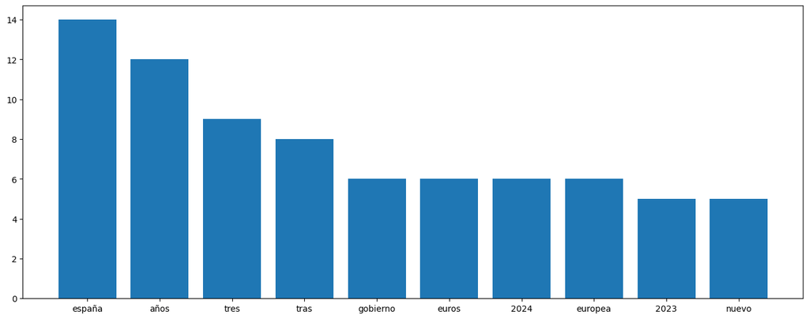

```python
def plot_bar(data=df_titulares, top=10):
    fig = plt.figure()
    ax = fig.add_axes([0,0,2,1])
    ax.bar(x =df_titulares.iloc[:top,:].index, height = df_titulares.iloc[:top,0].values)
    plt.show()

plot_bar()
```

## Creación de archivo HTML

> Recogemos todos los titulares en una lista

```python
lista_titulares = []

for auxTitular in allTitulares:
    if len(auxTitular) != 0:
        for titular in auxTitular:
            lista_titulares.append(titular) # Cogiendo el primer elemento ya que el segundo es el enlace

lista_titulares
```

```
[['Junts deja entrever que votará no y reclama una «amnistía integral que no deje a nadie atrás»',
  'https://www.lavozdegalicia.es/retransmision/espana/2024/01/30/congreso-vota-ley-amnistia-negativa-junts-apoyar-norma/01071706618179575855971.htm'],
 ['Abren juicio oral por asesinato contra cinco acusados de matar a Samuel Luiz en A Coruña',
  'https://www.lavozdegalicia.es/noticia/coruna/coruna/2024/01/30/abren-juicio-oral-contra-cinco-acusados-matar-samuel-luiz-coruna/00031706612046398338480.htm'],
 ['«Na Seguridade Social dixéronme que levaba ano e medio morto»',
  'https://www.lavozdegalicia.es/noticia/galicia/2024/01/30/span-langglna-seguridade-social-dixeronme-levaba-ano-medio-mortospan/0003_202401G30P11991.htm'],
 ['La inflación repunta tres décimas, hasta el 3,4 %, por la subida de la factura de la luz',
  'https://www.lavozdegalicia.es/noticia/economia/2024/01/30/inflacion-sube-tres-decimas-enero-34-precio-luz/00031706602742990271454.htm'],
 ['Los años negros de la comisaría de Ourense: robo de pistolas, anónimos y una muerte ahora archivada',
  'https://www.lavozdegalicia.es/noticia/galicia/2024/01/30/archivan-contra-policias-acusados-matar-companero/0003_202401G30P9991.htm'],
 ['Elon Musk anuncia que ya se implantó el primer chip cerebral de Neuralink en un ser humano',
  'https://www.lavozdegalicia.es/noticia/sociedad/2024/01/30/elon-musk-anuncia-implanto-primer-chip-cerebral-neuralink-humano/00031706597060318537851.htm'],
 ['Casi 1.200 gallegos perdieron la pensión no contributiva en el 2023 por superar el tope de ingresos',
  'https://www.lavozdegalicia.es/noticia/economia/2024/01/30/1200-gallegos-perdieron-pension-contributiva-2023-superar-tope-ingresos/0003_202401G30P29991.htm'],
 ['El italiano que mató a su expareja en Torremolinos también reconoce que emparedó a otra novia, pero que no la asesinó',
  'https://www.lavozdegalicia.es/noticia/espana/2024/01/30/italiano-mato-expareja-torremolinos-reconoce-emparedo-novia-asesino/00031706615613084784533.htm'],
 ['Las protestas de los agricultores europeos llegarán a España, pero serán «por regiones»',
  'https://www.lavozdegalicia.es/noticia/somosagro/2024/01/30/protestas-agricultores-europeos-llegaran-espana-seran-regiones/00031706620906149444422.htm'],
 ['Así participaron siete profesores de las escuelas de la ONU en la masacre de Hamás',
  'https://www.lavozdegalicia.es/noticia/internacional/2024/01/30/participaron-siete-profesores-escuelas-onu-masacre-hamas/00031706608685011641650.htm'],
 ['Un conductor de 24 años, pillado en Lugo circulando a 206 kilómetros por hora en un tramo limitado a 100',
  'https://www.lavozdegalicia.es/noticia/lugo/lugo/2024/01/30/conductor-24-anos-pillado-lugo-circulando-206-kilometros-hora-tramo-limitado-100/00031706617520496403100.htm'],
 ['Ayuda desde Suiza para la maltratada sin trabajo de Ribeira: «Cuando vi el titular y la foto en La Voz quedé bloqueada y hundida en la miseria»',
  'https://www.lavozdegalicia.es/noticia/barbanza/2024/01/30/ayuda-suiza-maltratada-ribeira-vi-titular-foto-me-quede-hundida/0003_202401B30C2991.htm'],
 ['Once años de cárcel para una educadora social por abusar de una menor de 13 años en un centro de Redondela',
  'https://www.lavozdegalicia.es/noticia/vigo/redondela/2024/01/30/once-anos-carcel-educadora-social-abusar-menor-cuidado-centro-redondela/0003_202401202401301706615391231.htm'],
 ['Felipe Oróns: «Estiven unha hora con todo o peso do Mercedes enriba do brazo»',
  'https://www.lavozdegalicia.es/noticia/carballo/laxe/2024/01/30/span-langglestiven-hora-peso-do-mercedes-enriba-do-brazo-esquerdospan/0003_202401C30C4992.htm'],
 ['El Celta cambia el césped de Balaídos por cuarta vez esta temporada',
  'https://www.lavozdegalicia.es/noticia/gradario/2024/01/30/celta-cambia-cesped-balaidos-cuarta-vez/00031706620955499741471.htm'],
 ['El rey Felipe VI cumple 56 años: «Vamos tirando»',
  'https://www.lavozdegalicia.es/noticia/sociedad/2024/01/30/rey-felipe-vi-cumple56-anos-vamos-tirando/00031706616438788318774.htm'],
 ['Un nuevo anticiclón de bloqueo protegerá a Galicia',
  'https://www.lavozdegalicia.es/noticia/sociedad/2024/01/29/lluvia-horizonte-meteorologico-gallego/00031706541979015591760.htm'],
 ['Las calçotadas se ponen de moda en Galicia: dónde, cómo y cúando disfrutarlas',
  'https://www.lavozdegalicia.es/noticia/yes/2024/01/27/calcotadas-moda-galicia1-escondita-2-golosia-3-casa-assumpta/0003_202401SY27P38991.htm'],
 ['Dejaron Venezuela tras un secuestro y montaron un taller en Pontevedra: «No podíamos seguir sufriendo»',
  'https://www.lavozdegalicia.es/noticia/pontevedra/2024/01/30/emprender-tras-huir-venezuela-salimos-dispuestos-/0003_202401P30C3991.htm'],
 ['El hartazgo de una santiaguesa por un árbol que se cuela en su salón: «Llevamos 20 años con estas vistas»',
  'https://www.lavozdegalicia.es/noticia/santiago/vivir-santiago/2024/01/30/hartazgo-santiaguesa-ramas-arbol-cuelan-salon-llevamos-20-anos-vistas/00031706606671302699680.htm'],
```

[output cut: 488 more lines]

```
  'https://elpais.com/escaparate/estilo-de-vida/2024-01-29/como-quitar-el-sarro-de-los-dientes.html'],
 ['Los mejores jamoneros para cortar jamón de forma cómoda',
  'https://elpais.com/escaparate/comparativas/2024-01-30/los-mejores-jamoneros-para-cortar-jamon-de-forma-comoda.html'],
 ['‘Brianeitor’, el nominado al Goya a quien los médicos dieron días de vida',
  'https://cadenaser.com/nacional/2024/01/29/jaume-roures-habla-sobre-las-palancas-del-real-madrid-yo-participe-en-una-de-ellas-por-valor-de-15000-millones-de-pesetas-cadena-ser/?afl=elpais'],
 ['José Manuel Soto da su opinión sobre el cartel de la semana santa de Sevilla: sorprenderá a muchos',
  'https://www.huffingtonpost.es/virales/jose-manuel-soto-da-opinion-sobre-cartel-semana-santa-sevilla-sorprendera.html'],
 ['Mbappé, desenlace inminente',
  'https://as.com/futbol/primera/mbappe-desenlace-inminente-n/?omnil=crossepportsup'],
 ['Microclimax musical: ¿por qué las canciones duran cada vez menos?',
  'https://retinatendencias.com/cultura-digital/microclimax-musical-por-que-las-canciones-duran-cada-vez-menos/'],
 ['Arturo Pérez-Reverte y su contundente respuesta sobre ‘Griselda’, el último gran estreno de Netflix',
  'https://as.com/meristation/noticias/arturo-perez-reverte-y-su-contundente-respuesta-sobre-griselda-el-ultimo-gran-estreno-de-netflix-n/'],
 ['El último concierto de los Beatles, en la azotea de Apple, cumple 55 años',
  'https://los40.com/los40/2019/01/29/los40classic/1548779356_737990.html?sdi=elpais_home_cardlos40']]
```

### Contador de palabras

```python
lista_titulos = []
palabras = []
contador_palabras={}

# Recogida del título del titular
for titular in lista_titulares:
    lista_titulos.append(titular[0])

# Recogida de las palabras del título
for titulo in lista_titulos:
    palabras_titulo = clean_texto.split(" ")
    for palabra in palabras_titulo:
        if (len(palabra)>=4 and len(palabra)<18):
            palabras.append(palabra)


# Creación del diccionario para ver cuantas veces se repite cada palabra
for palabra in palabras:
    if palabra in contador_palabras.keys():
        # Va sumando el número de veces que se repite la palabra
        contador_palabras[palabra][0]+=1
    else:
        # Si aún no se repite, se añade la palabra nueva al diccionario.
        contador_palabras[palabra]=[1]

contador_palabras

for palabra, contador in contador_palabras.items():
    if palabra == palabras[5]:
        print(f'{palabra} -> {contador[0]}')
```

```
amnistía -> 819
```

```python
#----- COSAS A TENER EN CUENTA ------
# TITULARES -> lista_titulares[i][0]
# URLS -> lista_titulares[i][1]
# PALABRAS Y CONTADOR -> contador_palabras
# CREAR UNA LISTA DE LISTAS CON: Titular, URL completa, peso do titular
#------------------------------------

def calculo_peso_ind(titular, palabras_contador = contador_palabras):
    # Lista para recoger las palabras válidas
    palabras_validas = []
    contador_p = 0
    peso_palabras_titular = 0   # Para calcular el número de repeticiones de cada palabra del titular
    peso_ind = 0 # El peso individual del titular

    # Recogida de las palabras en una lista
    palabras_tit = titular.split(" ")
    # Filtrado de palabras válidas
    for palabra in palabras_tit:
        if (len(palabra)>=4 and len(palabra)<18):
            palabras_validas.append(palabra)

    # palabras_validas: Lista con las palabras válidas de un titular

    # contador de palabras válidas en el titular, iterando ambas listas y comprobando las válidas
    for palabra in palabras_tit:
        for i in palabras_validas:
            if palabra == i:
                contador_p += 1

    # Contador de repeticiones de cada palabra
    for palabra, contador in contador_palabras.items():
        for i in palabras_validas:
            if palabra == i:
                # Voy haciendo la suma de las palabras
                peso_palabras_titular += int(contador[0])

    # Cálculo del peso individual
    peso_ind = round(float(peso_palabras_titular)/float(contador_p),2)

    # Retorno el titular y el peso individual para después averiguar el mayor para el peso relativo
    return titular, peso_ind

# Para el cálculo del peso individual más grande de los titulares
def peso_ind_mayor(lista):
    peso_mayor = 0
    for i in lista:
        # Si el nuevo peso es mayor que el anterior que se vaya actualizando
        if i > peso_mayor:
            peso_mayor = i
    return peso_mayor

# Cálculo de los pesos relativos de los titulares después de averiguar el peso individual MÁX
def calculo_relativo(peso_ind, peso_referente):
    peso_relativo = float(peso_ind)/float(peso_referente)
    return peso_relativo


lista_p = [0]
url_titular = ""


for h in lista_titulares:
    # Cálculo peso ind
    tit, pep = calculo_peso_ind(h[0])
    # Añadimos el peso a la lista de pesos individuales
    lista_p.append(pep)

# Averiguamos el peso individual máximo del listado de titulares
peso_mayor_individual = peso_ind_mayor(lista_p)
```

### Creamos la lista de titulares con su correspondiente URL y peso relativo

```python
registro_titular = []

for y in lista_titulares:
    registro_individial_tit = []
    # Cálculo peso ind
    tit, pep = calculo_peso_ind(y[0])
    # Guardamos el registro de la URL del titular
    url_titular = y[1]
    peso_relativo_tit = round(calculo_relativo(pep, peso_mayor_individual),3)

    # Guardamos el registro del titular completo
    registro_individial_tit.append(tit)
    registro_individial_tit.append(url_titular)
    registro_individial_tit.append(peso_relativo_tit)

    # Añado el registro al registro final
    registro_titular.append(registro_individial_tit)

print(registro_titular)
```

```
[['Junts deja entrever que votará no y reclama una «amnistía integral que no deje a nadie atrás»', 'https://www.lavozdegalicia.es/retransmision/espana/2024/01/30/congreso-vota-ley-amnistia-negativa-junts-apoyar-norma/01071706618179575855971.htm', 0.28], ['Abren juicio oral por asesinato contra cinco…
```

> Ordenamos el listado de listas por relevancia

```python
registro_titular = sorted(registro_titular, key=lambda x: x[2], reverse=True)
```

## Muestra de los 20 titulares con mayor peso relativo

```python
registro_titular[:20]
```

```
[['La inflación aumenta tres décimas en enero y repunta al 3,4%',
  'https://elpais.com/economia/2024-01-30/la-inflacion-sube-tres-decimas-en-el-arranque-de-ano-al-repuntar-al-34-en-enero.html',
  1.0],
 ['Once años de cárcel para una educadora social por abusar de una menor de 13 años en un centro de Redondela',
  'https://www.lavozdegalicia.es/noticia/vigo/redondela/2024/01/30/once-anos-carcel-educadora-social-abusar-menor-cuidado-centro-redondela/0003_202401202401301706615391231.htm',
  0.969],
 ['El último concierto de los Beatles, en la azotea de Apple, cumple 55 años',
  'https://los40.com/los40/2019/01/29/los40classic/1548779356_737990.html?sdi=elpais_home_cardlos40',
  0.95],
 ['‘Mac and cheese’ de autor con solo tres ingredientes',
  'https://elpais.com/gastronomia/el-comidista/2024-01-29/mac-and-cheese-de-autor-con-solo-tres-ingredientes.html',
  0.933],
 ['La generación Z española, líder europea en poliamor',
  'https://elpais.com/eps/2024-01-23/la-generacion-z-espanola-lider-europea-en-poliamor.html',
  0.91],
 ['Los unionistas levantan dos años de bloqueo al autogobierno de Irlanda del Norte',
  'https://elpais.com/internacional/2024-01-30/los-unionistas-levantan-dos-anos-de-bloqueo-al-autogobierno-de-irlanda-del-norte.html',
  0.85],
 ['La inflación repunta tres décimas, hasta el 3,4 %, por la subida de la factura de la luz',
  'https://www.lavozdegalicia.es/noticia/economia/2024/01/30/inflacion-sube-tres-decimas-enero-34-precio-luz/00031706602742990271454.htm',
  0.75],
 ['La Justicia europea valida el anonimato de una madre que da en adopción un hijo',
  'https://www.lavozdegalicia.es/noticia/sociedad/2024/01/30/justicia-europea-valida-anonimato-madre-da-adopcion-hijo/00031706618322903720409.htm',
  0.75],
 ['EE UU confundió el dron que mató a tres de sus militares en Jordania con uno propio',
  'https://elpais.com/internacional/2024-01-29/ee-uu-confundio-el-dron-que-mato-a-tres-de-sus-militares-en-jordania-con-uno-propio.html',
  0.75],
 ['Los placeres de viajar llegada la jubilación: tres trotamundos nos lo cuentan',
  'https://elpais.com/elviajero/2024-01-28/los-placeres-de-viajar-llegada-la-jubilacion-tres-trotamundos-nos-lo-cuentan.html',
  0.75],
 ['El ejército israelí mata a tres milicianos palestinos en un hospital de Cisjordania',
  'https://elpais.com/internacional/2024-01-30/guerra-entre-israel-y-gaza-en-directo.html',
  0.744],
 ['La fórmula para ser un superanciano: «Tienen una memoria de alguien 30 años menor»',
  'https://www.lavozdegalicia.es/noticia/lavozdelasalud/vida-saludable/2024/01/29/formula-superanciano-memoria-alguien-30-anos-menor/00031706550057792766129.htm',
  0.7],
 ['Vox se parte en dos en Baleares tras un conflicto con la dirección nacional',
  'https://www.lavozdegalicia.es/noticia/espana/2024/01/29/vox-baleares-expulsa-grupo-parlamentario-presidente-parlament-presidenta-partido/00031706527155250396926.htm',
  0.7],
 ['¿Es posible una cadena de valor de minerales críticos europea sin tecnología de China?',
  'https://cincodias.elpais.com/economia/2024-01-30/es-posible-una-cadena-de-valor-de-minerales-criticos-europeo-sin-tecnologia-de-china.html',
  0.7],
 ['El caso de la pintura valorada en 600 euros que se vendió por 72.000',
  'https://elpais.com/icon-design/2024-01-30/un-timo-con-mucho-arte-el-curioso-caso-de-la-pintura-valorada-en-600-euros-que-acabo-vendiendose-por-72-mil.html',
  0.7],
 ['Sancionada la patinadora Kamila Valieva con cuatro años de suspensión por dopaje',
  'https://elpais.com/deportes/2024-01-29/la-patinadora-kamila-valieva-es-sancionada-con-cuatro-anos-de-suspension-por-dopaje.html',
  0.7],
 ['Condenado a 10 años de cárcel el ex primer ministro de Pakistán Imran Khan 10 días antes de las elecciones',
  'https://elpais.com/internacional/2024-01-30/condenado-a-10-anos-de-carcel-el-ex-primer-ministro-de-pakistan-imran-khan-10-dias-antes-de-las-elecciones.html',
  0.7],
 ['Los años negros de la comisaría de Ourense: robo de pistolas, anónimos y una muerte ahora archivada',
  'https://www.lavozdegalicia.es/noticia/galicia/2024/01/30/archivan-contra-policias-acusados-matar-companero/0003_202401G30P9991.htm',
  0.665],
 ['Solo cinco autonomías registran mejores datos en abandono escolar que la media europea',
  'https://elpais.com/educacion/2024-01-29/solo-cinco-autonomias-registran-mejores-datos-en-abandono-escolar-que-la-media-europea.html',
  0.665],
 ['Los salarios de tres millones de empleados públicos subirán otro 0,5% por la mejora del PIB',
  'https://elpais.com/economia/2024-01-30/los-salarios-de-mas-de-tres-millones-de-empleados-publicos-subiran-otro-05-por-la-mejora-del-pib.html',
  0.661]]
```

## Creación del archivo HTML con los titulares ordenados

> Obtenemos la fecha actual para la creación del HTML actualizado

```python
fecha_actual = date.today()
# Convertir la fecha a cadena de texto
fecha_cadena = fecha_actual.strftime("%Y-%m-%d")


# Método que genera los p correspondientes de cada título
def generador_html(registro = registro_titular):
    cadena_p = ""
    linea = ""
    for i in registro:
        linea = f'<p style="font-size: {i[2]+1}em;"><a href={i[1]}>{i[0]}</a></p>\n'
        cadena_p += linea

        #Reseteo de la variable para impedir que se repitan los datos
        linea = ""
    return cadena_p

parrafos = generador_html()

file_html = open(f"resultado-{fecha_cadena}.html", "w")

file_html.write(f'''<html>
<head>
<title>Titulares ordenados</title>
</head>
<body>
<h1>Titulares</h1>
{parrafos}
</body>
</html>''')

file_html.close()
```

## PREGUNTA

### Sugiere un método mejor para analizar la relevancia de los titulares

Un buen método que se me ocurre para analizar la relevancia de los titulares podría ser el **scraping de las interacciones** correspondientes a cada titular; con esto me refiero a que el número de lecturas, comentarios y las acciones sociales también pueden proporcionar información sobre la relevancia de los titulares.  
Un ejemplo sería raspar el número de comentarios y opiniones de cada titular y como resultado crear un ranking de los titulares más relevantes en España.

## SQLite

> Importamos sqlite3

```python
import sqlite3
```

En el registro tenemos guardados el titular, URL y peso relativo, nos hace falta sacar ahora el medio al que pertenece cada titular. Para ello trabajaremos con el diccionario sacado del json inicial de donde sacamos los medios digitales y con el listado del registro que plasmámos en el HTML.

```python
enderezos
```

```
{'La Voz de Galicia': {'url': 'https://www.lavozdegalicia.es',
  'tag': 'h4',
  'clase': 'a-min-headline'},
 'El País': {'url': 'https://www.elpais.com', 'tag': 'h2', 'clase': 'c_t'},
 'El Mundo': {'url': 'https://www.elmundo.es',
  'tag': 'h2',
  'clase': 'ue-c-cover-content-link'},
 'ABC': {'url': 'https://www.abc.es/',
  'tag': 'h2',
  'clase': 'voc-title voc-title--s18-fxs20'},
 'El Economista': {'url': 'https://www.eleconomista.es/',
  'tag': 'div',
  'clase': 'articleHeadline'},
 'Vozpopuli': {'url': 'https://www.vozpopuli.com/',
  'tag': 'div',
  'clase': 'post-content'}}
```

```python
# lista = [[0,1],[2,3]]
# for i in lista:
    # if i == lista[0]:
        # i.append(3)
# print(lista)
lista_medio = []
for i,d in enderezos.items():
    medio = ""
    url = ""
    lista_puntero = []

    medio = i
    url = d["url"]

    lista_puntero.append(medio)
    lista_puntero.append(url)
    lista_medio.append(lista_puntero)

lista_medio
```

```
[['La Voz de Galicia', 'https://www.lavozdegalicia.es'],
 ['El País', 'https://www.elpais.com'],
 ['El Mundo', 'https://www.elmundo.es'],
 ['ABC', 'https://www.abc.es/'],
 ['El Economista', 'https://www.eleconomista.es/'],
 ['Vozpopuli', 'https://www.vozpopuli.com/']]
```

> Voy a realizar una extracción del nombre de cada medio para comprobar despues si lo contiene la URL de cada titular ya que no todas las noticias empiezan por la URL principal del medio completa, tienen algunas variaciones.

```python
import re

cadena = "https://www.elmundo.es/"

# Entonces actualizamos el listado anterior sustituyendo la URL por el pedazo de URL que todas sus noticias continen

for i in lista_medio:
    nombre_medio = re.search(r"https://www\.(.+)\.(.+)", i[1]).group(1)
    i[1] = nombre_medio

lista_medio
```

```
[['La Voz de Galicia', 'lavozdegalicia'],
 ['El País', 'elpais'],
 ['El Mundo', 'elmundo'],
 ['ABC', 'abc'],
 ['El Economista', 'eleconomista'],
 ['Vozpopuli', 'vozpopuli']]
```

```python
contador = 0

for i in registro_titular:
  # Inicializamos el contador una vez se añada el medio correspondiente al anterior registro
  contador = 0
  # Itero el número de medios de los que está conformado el json
  while contador != (len(lista_medio) - 1):
    # Compruebo de que medio es cada titular según el inicio de su URL iterando cada uno
    if lista_medio[contador][1] in i[1]:
      # Añado a la lista general de los registros su correspondiente medio
      i.append(lista_medio[contador][0])
    contador += 1

  """
  Si no se encontró la url conocida, es publicidad"""
  if len(i) < 4:
    i.append("publicidad")
```

> Comprobamos si se ha añadido con éxito el medio a cada titular del registro general

```python
registro_titular[:10]
```

```
[['La inflación aumenta tres décimas en enero y repunta al 3,4%',
  'https://elpais.com/economia/2024-01-30/la-inflacion-sube-tres-decimas-en-el-arranque-de-ano-al-repuntar-al-34-en-enero.html',
  1.0,
  'El País'],
 ['Once años de cárcel para una educadora social por abusar de una menor de 13 años en un centro de Redondela',
  'https://www.lavozdegalicia.es/noticia/vigo/redondela/2024/01/30/once-anos-carcel-educadora-social-abusar-menor-cuidado-centro-redondela/0003_202401202401301706615391231.htm',
  0.969,
  'La Voz de Galicia'],
 ['El último concierto de los Beatles, en la azotea de Apple, cumple 55 años',
  'https://los40.com/los40/2019/01/29/los40classic/1548779356_737990.html?sdi=elpais_home_cardlos40',
  0.95,
  'El País'],
 ['‘Mac and cheese’ de autor con solo tres ingredientes',
  'https://elpais.com/gastronomia/el-comidista/2024-01-29/mac-and-cheese-de-autor-con-solo-tres-ingredientes.html',
  0.933,
  'El País'],
 ['La generación Z española, líder europea en poliamor',
  'https://elpais.com/eps/2024-01-23/la-generacion-z-espanola-lider-europea-en-poliamor.html',
  0.91,
  'El País'],
 ['Los unionistas levantan dos años de bloqueo al autogobierno de Irlanda del Norte',
  'https://elpais.com/internacional/2024-01-30/los-unionistas-levantan-dos-anos-de-bloqueo-al-autogobierno-de-irlanda-del-norte.html',
  0.85,
  'El País'],
 ['La inflación repunta tres décimas, hasta el 3,4 %, por la subida de la factura de la luz',
  'https://www.lavozdegalicia.es/noticia/economia/2024/01/30/inflacion-sube-tres-decimas-enero-34-precio-luz/00031706602742990271454.htm',
  0.75,
  'La Voz de Galicia'],
 ['La Justicia europea valida el anonimato de una madre que da en adopción un hijo',
  'https://www.lavozdegalicia.es/noticia/sociedad/2024/01/30/justicia-europea-valida-anonimato-madre-da-adopcion-hijo/00031706618322903720409.htm',
  0.75,
  'La Voz de Galicia'],
 ['EE UU confundió el dron que mató a tres de sus militares en Jordania con uno propio',
  'https://elpais.com/internacional/2024-01-29/ee-uu-confundio-el-dron-que-mato-a-tres-de-sus-militares-en-jordania-con-uno-propio.html',
  0.75,
  'El País'],
 ['Los placeres de viajar llegada la jubilación: tres trotamundos nos lo cuentan',
  'https://elpais.com/elviajero/2024-01-28/los-placeres-de-viajar-llegada-la-jubilacion-tres-trotamundos-nos-lo-cuentan.html',
  0.75,
  'El País']]
```

### Estableciendo conexión y cursor

```python
con = sqlite3.connect("noticias.db")
cur = con.cursor()
```

### Creación de tabla de datos

```python
try:
    cur.execute("CREATE TABLE noticia(titular, url, p_relativo, medio)")
except Exception:
    print("La tabla ya está creada")
```

```
La tabla ya está creada
```

### Carga de datos

```python
cur.executemany("INSERT INTO noticia(titular, url, p_relativo,medio) VALUES (?,?,?,?)", registro_titular) # Para trabajar con parámetros
con.commit()
```

```python
sentencia = "SELECT titular, url, p_relativo, medio FROM noticia"
for fila in cur.execute(sentencia): #Para devolver valores
    print(fila)
```

```
('La inflación aumenta tres décimas en enero y repunta al 3,4%', 'https://elpais.com/economia/2024-01-30/la-inflacion-sube-tres-decimas-en-el-arranque-de-ano-al-repuntar-al-34-en-enero.html', 1.0, 'El País')
('Once años de cárcel para una educadora social por abusar de una menor de 13 años en un centro de Redondela', 'https://www.lavozdegalicia.es/noticia/vigo/redondela/2024/01/30/once-anos-carcel-educadora-social-abusar-menor-cuidado-centro-redondela/0003_202401202401301706615391231.htm', 0.969, 'La Vo…
('El último concierto de los Beatles, en la azotea de Apple, cumple 55 años', 'https://los40.com/los40/2019/01/29/los40classic/1548779356_737990.html?sdi=elpais_home_cardlos40', 0.95, 'El País')
('‘Mac and cheese’ de autor con solo tres ingredientes', 'https://elpais.com/gastronomia/el-comidista/2024-01-29/mac-and-cheese-de-autor-con-solo-tres-ingredientes.html', 0.933, 'El País')
('La generación Z española, líder europea en poliamor', 'https://elpais.com/eps/2024-01-23/la-generacion-z-espanola-lider-europea-en-poliamor.html', 0.91, 'El País')
('Los unionistas levantan dos años de bloqueo al autogobierno de Irlanda del Norte', 'https://elpais.com/internacional/2024-01-30/los-unionistas-levantan-dos-anos-de-bloqueo-al-autogobierno-de-irlanda-del-norte.html', 0.85, 'El País')
('La inflación repunta tres décimas, hasta el 3,4 %, por la subida de la factura de la luz', 'https://www.lavozdegalicia.es/noticia/economia/2024/01/30/inflacion-sube-tres-decimas-enero-34-precio-luz/00031706602742990271454.htm', 0.75, 'La Voz de Galicia')
('La Justicia europea valida el anonimato de una madre que da en adopción un hijo', 'https://www.lavozdegalicia.es/noticia/sociedad/2024/01/30/justicia-europea-valida-anonimato-madre-da-adopcion-hijo/00031706618322903720409.htm', 0.75, 'La Voz de Galicia')
('EE UU confundió el dron que mató a tres de sus militares en Jordania con uno propio', 'https://elpais.com/internacional/2024-01-29/ee-uu-confundio-el-dron-que-mato-a-tres-de-sus-militares-en-jordania-con-uno-propio.html', 0.75, 'El País')
('Los placeres de viajar llegada la jubilación: tres trotamundos nos lo cuentan', 'https://elpais.com/elviajero/2024-01-28/los-placeres-de-viajar-llegada-la-jubilacion-tres-trotamundos-nos-lo-cuentan.html', 0.75, 'El País')
('El ejército israelí mata a tres milicianos palestinos en un hospital de Cisjordania', 'https://elpais.com/internacional/2024-01-30/guerra-entre-israel-y-gaza-en-directo.html', 0.744, 'El País')
('La fórmula para ser un superanciano: «Tienen una memoria de alguien 30 años menor»', 'https://www.lavozdegalicia.es/noticia/lavozdelasalud/vida-saludable/2024/01/29/formula-superanciano-memoria-alguien-30-anos-menor/00031706550057792766129.htm', 0.7, 'La Voz de Galicia')
('Vox se parte en dos en Baleares tras un conflicto con la dirección nacional', 'https://www.lavozdegalicia.es/noticia/espana/2024/01/29/vox-baleares-expulsa-grupo-parlamentario-presidente-parlament-presidenta-partido/00031706527155250396926.htm', 0.7, 'La Voz de Galicia')
('¿Es posible una cadena de valor de minerales críticos europea sin tecnología de China?', 'https://cincodias.elpais.com/economia/2024-01-30/es-posible-una-cadena-de-valor-de-minerales-criticos-europeo-sin-tecnologia-de-china.html', 0.7, 'El País')
('El caso de la pintura valorada en 600 euros que se vendió por 72.000', 'https://elpais.com/icon-design/2024-01-30/un-timo-con-mucho-arte-el-curioso-caso-de-la-pintura-valorada-en-600-euros-que-acabo-vendiendose-por-72-mil.html', 0.7, 'El País')
('Sancionada la patinadora Kamila Valieva con cuatro años de suspensión por dopaje', 'https://elpais.com/deportes/2024-01-29/la-patinadora-kamila-valieva-es-sancionada-con-cuatro-anos-de-suspension-por-dopaje.html', 0.7, 'El País')
('Condenado a 10 años de cárcel el ex primer ministro de Pakistán Imran Khan 10 días antes de las elecciones', 'https://elpais.com/internacional/2024-01-30/condenado-a-10-anos-de-carcel-el-ex-primer-ministro-de-pakistan-imran-khan-10-dias-antes-de-las-elecciones.html', 0.7, 'El País')
```

[output cut: 256 more lines]

```python
res2=cur.execute(sentencia)
res2.fetchall()
```

```
[('La inflación aumenta tres décimas en enero y repunta al 3,4%',
  'https://elpais.com/economia/2024-01-30/la-inflacion-sube-tres-decimas-en-el-arranque-de-ano-al-repuntar-al-34-en-enero.html',
  1.0,
  'El País'),
 ('Once años de cárcel para una educadora social por abusar de una menor de 13 años en un centro de Redondela',
  'https://www.lavozdegalicia.es/noticia/vigo/redondela/2024/01/30/once-anos-carcel-educadora-social-abusar-menor-cuidado-centro-redondela/0003_202401202401301706615391231.htm',
  0.969,
  'La Voz de Galicia'),
 ('El último concierto de los Beatles, en la azotea de Apple, cumple 55 años',
  'https://los40.com/los40/2019/01/29/los40classic/1548779356_737990.html?sdi=elpais_home_cardlos40',
  0.95,
  'El País'),
 ('‘Mac and cheese’ de autor con solo tres ingredientes',
  'https://elpais.com/gastronomia/el-comidista/2024-01-29/mac-and-cheese-de-autor-con-solo-tres-ingredientes.html',
  0.933,
  'El País'),
 ('La generación Z española, líder europea en poliamor',
  'https://elpais.com/eps/2024-01-23/la-generacion-z-espanola-lider-europea-en-poliamor.html',
  0.91,
  'El País'),
 ('Los unionistas levantan dos años de bloqueo al autogobierno de Irlanda del Norte',
  'https://elpais.com/internacional/2024-01-30/los-unionistas-levantan-dos-anos-de-bloqueo-al-autogobierno-de-irlanda-del-norte.html',
  0.85,
  'El País'),
 ('La inflación repunta tres décimas, hasta el 3,4 %, por la subida de la factura de la luz',
  'https://www.lavozdegalicia.es/noticia/economia/2024/01/30/inflacion-sube-tres-decimas-enero-34-precio-luz/00031706602742990271454.htm',
  0.75,
  'La Voz de Galicia'),
 ('La Justicia europea valida el anonimato de una madre que da en adopción un hijo',
  'https://www.lavozdegalicia.es/noticia/sociedad/2024/01/30/justicia-europea-valida-anonimato-madre-da-adopcion-hijo/00031706618322903720409.htm',
  0.75,
  'La Voz de Galicia'),
 ('EE UU confundió el dron que mató a tres de sus militares en Jordania con uno propio',
  'https://elpais.com/internacional/2024-01-29/ee-uu-confundio-el-dron-que-mato-a-tres-de-sus-militares-en-jordania-con-uno-propio.html',
  0.75,
  'El País'),
 ('Los placeres de viajar llegada la jubilación: tres trotamundos nos lo cuentan',
  'https://elpais.com/elviajero/2024-01-28/los-placeres-de-viajar-llegada-la-jubilacion-tres-trotamundos-nos-lo-cuentan.html',
  0.75,
  'El País'),
```

[output cut: 1034 more lines]

```
  'https://www.lavozdegalicia.es/noticia/pontevedra/bueu/2024/01/30/adios-luis-gomez-exjefe-policia-local-bueu/00031706611294881108959.htm',
  0.05,
  'La Voz de Galicia'),
 ('Riki Blanco',
  'https://elpais.com/opinion/2024-01-30/riki-blanco.html',
  0.0,
  'El País'),
 ('Vídeo | Angy Fernández, Miss Caffeina o Nebulossa: ¿quién es quién?',
  'https://elpais.com/videos/2024-01-29/video-angy-fernandez-miss-caffeina-o-nebulossa-quien-es-quien-en-el-benidorm-fest-2024.html?autoplay=1',
  0.0,
  'El País'),
 ('Crucigrama de Mambrino',
  'https://elpais.com/juegos/crucigramas/mambrino/#?int=juegos_bloque_home',
  0.0,
  'El País')]
```

```python
con.close()
```